# geoTwitter to #Russia2018

Ricardo Garcia Ruiz

2 de julio, 2018

# 1 Práctica 1: Análisis de datos geoespaciales

## 1.1 Enunciado

> Este documento recoge la práctica de la asignatura **“Análisis de Datos Geoespaciales”**. Se plantean dos ejercicios independientes; ambos ejercicios deben resolverse de forma individual y autónoma por el estudiante. Para la resolución de los ejercicios podrán emplearse como apoyo los materiales del aula y contenidos de internet.

# 2 Ejercicio 1: Análisis geocodificado de tweets

El análisis geográfico de las aportaciones de usuarios de redes sociales como Twitter o Facebook ha ido ganando relevancia en los últimos años como herramienta para el estudio de fenómenos socioculturales. En el ejercicio se plantea el uso de la red social Twitter.

El objetivo del ejercicio es geocodificar, a nivel país, la procedencia de los usuarios que han utilizado un hashtag o etiqueta determinada (a elegir por el estudiante). A partir de los tweets individuales obtenidos de la red social, se propone la generación de un mapa que muestre el número de tweets por país. El mapa, tematizado convenientemente, será publicado en la aplicación GIS en la nube ArcGIS Online.

## 2.1 Desarrollo

Se propone al estudiante seleccionar un hashtag (por ejemplo “#Eurovision2018”) y realizar una búsqueda de tweets que contengan la etiqueta seleccionada. Para ello, se propone, en el Anexo I del presente documento, un método de geocodificación de los usuarios autores de los tweets. Una vez geocodificados los usuarios (a partir de la información de localización asociada a cada perfil de usuario), se realizará un análisis geográfico que contabilizará el número de usuarios por país. Se propone utilizar la misma capa (shapefile) de países que se empleó en la PEC1 y disponible en el aula (Fichero PAISES_GENERALIZADOS.rar). Todo éste proceso será desarrollado utilizando R.

El shapefile resultante de éste análisis se subirá a la plataforma ArcGIS Online y se tematizará convenientemente. Una vez finalizado, el mapa será compartido con el profesor (jde_diegoa@uoc.edu). Se incluirá también la URL del mapa en el documento de entrega que se subirá al Registro de Evaluación Continua del Aula. Nota: Ha de tenerse en cuenta que en este ejercicio se utilizarán APIs de acceso gratuito pero limitado. Se busca que el estudiante obtenga al menos 500 resultados válidos geocodificados a nivel país (como mínimo).

## 2.2 Resolución Ejercicio 1

### 2.2.1 Carga de los elementos de acceso a Twitter

En primer lugar obtenemos las claves de acceso a Twitter según el manual de procedimiento de la práctica.

Una vez adquiridas procedemos a cargarlas en variables en R para poder aplicarlas a una función de acceso a Twitter desde el entorno de RStudio:

```r
# variables de acceso a Twitter mediante R a geoTwitterRussia2018
consumer_key <- "Djv1QIHp5DCTtFZDF4P7PmKhe"
consumer_secret <- "PXwhHVALeuGnH5Myn4qLzwfM0YUHCX67Ife8tlujhzAGI0lwYe"
access_token <- "287839706-VlvixPev6CuRnMwAlNn5U7VeVEafgh3JMWCHqUvL"
access_secret <- "csorAvqaLS82yU2hhJj5pZvBHPNQtOOVd04ZV7gwJWTWH"
```

Ahora procedemos a ajustar las funciones de handshake de autenticación OAuth del paquete httr para una sesión twitteR. Esto lo hacemos mediante la siguiente función de carga:

```r
# Esta función ajusta las funciones de handshake de autenticación
# OAuth del paquete httr para una sesión twitteR
setup_twitter_oauth(consumer_key,consumer_secret, access_token, access_secret)
```

```
## [1] "Using direct authentication"
```

En el momento de ejecutar esta función se nos permite optar por ajuste del OAuth permanentemente o bien hacerlo por cada sesión. Nosotros optamos por el modo permanente.

### 2.2.2 Acceso a Twitter desde R para carga de twitts

A continuación, procedemos a delimitar el tipo de hashtag que vamos a utilizar. Aunque hemos estado dudando entre utilizar ‘#Russia2018’ o bien combinado con ‘#WorldCup’, finalmente optamos solo por la versión sencilla:

```r
# Hashtag definitivo
searchTerm <- "#Russia2018"
```

```r
# Número máximo de twitts
searchResults <- searchTwitter(searchTerm, n = 15000)
```

Además, como se ve, se pide la carga de 15000 twitts máximo.

### 2.2.3 Tratamiento de los datos descargados de Twitter

A continuación convertimos la lista con los resultados obtenidos en un data.frame manejable en R:

```r
# convierte la lista de resultados searchResult en un dataframe
tweetFrame <- twListToDF(searchResults)
```

Detalle del dataframe tweetFrame

[output not shown]

favorited

favoriteCount

replyToSN

[output not shown]

truncated

replyToSID

[output not shown]

Length:15000

Mode :logical

Min. : 0,000

Length:15000

Min. :2018-06-28 15:20:36

Mode :logical

Length:15000

Length:15000

Class :character

FALSE:15000

1st Qu.: 0,000

Class :character

1st Qu.:2018-06-28 17:38:44

FALSE:11157

Class :character

Class :character

Mode :character

NA

Median : 0,000

Mode :character

Median :2018-06-28 20:56:39

TRUE :3843

Mode :character

Mode :character

NA

NA

Mean : 1,421

NA

Mean :2018-06-29 01:08:13

NA

NA

NA

NA

NA

3rd Qu.: 0,000

NA

3rd Qu.:2018-06-29 09:29:42

NA

NA

NA

NA

NA

Max. :2420,000

NA

Max. :2018-06-29 18:31:38

NA

NA

NA

Detalle del dataframe tweetFrame

|  | replyToUID | statusSource | screenName | retweetCount | isRetweet | retweeted | longitude | latitude |
| --- | --- | --- | --- | --- | --- | --- | --- | --- |
|  | Length:15000 | Length:15000 | Length:15000 | Min. : 0,0 | Mode :logical | Mode :logical | Length:15000 | Length:15000 |
|  | Class :character | Class :character | Class :character | 1st Qu.: 0,0 | FALSE:7073 | FALSE:15000 | Class :character | Class :character |
|  | Mode :character | Mode :character | Mode :character | Median : 2,0 | TRUE :7927 | NA | Mode :character | Mode :character |
|  | NA | NA | NA | Mean : 125,5 | NA | NA | NA | NA |
|  | NA | NA | NA | 3rd Qu.: 39,0 | NA | NA | NA | NA |
|  | NA | NA | NA | Max. :23244,0 | NA | NA | NA | NA |

En este momento generamos una lista de los usuarios que han emitido twits sobre los datos obtenidos en **tweetFrame**:

```r
# lista (userInfo) a partir del listado de usuarios asociados a los tweets anteriores

# como calcularla completa da un error persistente se calcula por
# tramos y luego se une en una sola lista
userInfo <- lookupUsers(tweetFrame$screenName[1:5000])
userInfo2 <- lookupUsers(tweetFrame$screenName[5001:10000])

# Da error:
# Error in twInterfaceObj$doAPICall(paste("users", "lookup", sep = "/"),  :
#                                    Forbidden (HTTP 403).
#userInfo3 <- lookupUsers(tweetFrame$screenName[10001:15000])

userInfo3 <- lookupUsers(tweetFrame$screenName[10001:13900])
userInfo4 <- lookupUsers(tweetFrame$screenName[13450:15000])

# fusionamos los datos en una sola lista
userInfo = c(userInfo, userInfo2, userInfo3, userInfo4)

# borramos las variables no necesarias
rm(userInfo2, userInfo3, userInfo4)
```

```r
# salvamos la lista obtenida en el sistema
save(userInfo, file = "userInfo.RData")
```

Ahora pasamos a convertir esta lista en un dataframe que podamos utilizar con mayor comodidad en los cálculos posteriores:

```r
# Convertimos la lista en dataFrame
userFrame <- twListToDF(userInfo)
```

Detalle del dataframe userFrame

description

statusesCount

followersCount

favoritesCount

friendsCount

[output not shown]

[output not shown]

[output not shown]

Length:12117

Min. : 0

Min. : 0

Min. : 0

Min. : 0

Length:12117

Length:12117

Min. :2006-11-30 09:18:03

Class :character

1st Qu.: 1298

1st Qu.: 113

1st Qu.: 242

1st Qu.: 170

Class :character

Class :character

1st Qu.:2011-01-14 18:12:16

Mode :character

Median : 5965

Median : 370

Median : 1424

Median : 440

Mode :character

Mode :character

Median :2012-11-16 07:38:11

NA

Mean : 27078

Mean : 11816

Mean : 10191

Mean : 1167

NA

NA

Mean :2013-05-29 02:28:37

NA

3rd Qu.: 23036

3rd Qu.: 1253

3rd Qu.: 6745

3rd Qu.: 1022

NA

NA

3rd Qu.:2016-01-03 11:26:25

NA

Max. :2187550

Max. :10865141

Max. :681598

Max. :245943

NA

NA

Max. :2018-06-29 18:22:56

Detalle del dataframe userFrame

protected

verified

screenName

location

[output not shown]

[output not shown]

listedCount

followRequestSent

Mode :logical

Mode :logical

Length:12117

Length:12117

Length:12117

Length:12117

Min. : 0,00

Mode :logical

FALSE:12108

FALSE:11745

Class :character

Class :character

Class :character

Class :character

1st Qu.: 0,00

FALSE:12117

TRUE :9

TRUE :372

Mode :character

Mode :character

Mode :character

Mode :character

Median : 5,00

NA

NA

NA

NA

NA

NA

NA

Mean : 67,56

NA

NA

NA

NA

NA

NA

NA

3rd Qu.: 24,00

NA

NA

NA

NA

NA

NA

NA

Max. :21506,00

NA

Finalmente, filtramos el dataframe de forma que mantengamos solo los datos de los usuarios de los que podamos obtener su localización geográfica:

```r
# Filtramos el dataFrame obteniendo el listado de todos aquellos usuarios
# que introdujeron información relativa a su localización
addresses <- userFrame[userFrame$location !="",]
```

Detalle del dataframe addresses

description

statusesCount

followersCount

favoritesCount

friendsCount

[output not shown]

[output not shown]

[output not shown]

Length:8724

Min. : 0

Min. : 0

Min. : 0

Min. : 0

Length:8724

Length:8724

Min. :2006-11-30 09:18:03

Class :character

1st Qu.: 1679

1st Qu.: 155

1st Qu.: 293

1st Qu.: 208

Class :character

Class :character

1st Qu.:2010-09-21 16:07:27

Mode :character

Median : 7053

Median : 458

Median : 1664

Median : 516

Mode :character

Mode :character

Median :2012-06-03 07:03:16

NA

Mean : 27130

Mean : 13672

Mean : 10321

Mean : 1300

NA

NA

Mean :2013-01-31 00:30:53

NA

3rd Qu.: 24709

3rd Qu.: 1459

3rd Qu.: 7296

3rd Qu.: 1164

NA

NA

3rd Qu.:2015-07-20 21:04:21

NA

Max. :1195425

Max. :10865141

Max. :644352

Max. :245943

NA

NA

Max. :2018-06-29 16:03:51

Detalle del dataframe addresses

protected

verified

screenName

location

[output not shown]

[output not shown]

listedCount

followRequestSent

Mode :logical

Mode :logical

Length:8724

Length:8724

Length:8724

Length:8724

Min. : 0,00

Mode :logical

FALSE:8717

FALSE:8426

Class :character

Class :character

Class :character

Class :character

1st Qu.: 1,00

FALSE:8724

TRUE :7

TRUE :298

Mode :character

Mode :character

Mode :character

Mode :character

Median : 7,00

NA

NA

NA

NA

NA

NA

NA

Mean : 68,23

NA

NA

NA

NA

NA

NA

NA

3rd Qu.: 28,00

NA

NA

NA

NA

NA

NA

NA

Max. :11726,00

NA

### 2.2.4 Búsqueda de los datos geográficos de los twitts: latitud y longitud

Gestionamos la geo localización de longitud y latitud de los twitts que tienen informado correctamente (o al menos que se pueda utilizar en la localización) el pais/localidad en el dataframe ‘addresses’.

Para ello consultamos la dirección de internet http://nominatim.openstreetmap.org ya que otras alternativas eran menos fiables para consultar todos los twitts de nuestra lista.

De nuestro dataframe utilizamos el campo ‘location’ y utilizando la función geocode_OSM() nos da como retorno la longitud y latitud de cada twitt:

```r
# Creamos un dataframe vacio para guardar todos los datos finales obtenidos
geocoded_02 <- data.frame()

# Manejamos un loop en el que accederemos a la función geocode_OSM()
# suministrandoles uno a uno los parámetros
for( i in 1:nrow(addresses) ){

  # Creamos una dataframe estandar para los datos que necesitamos obtener
  answer <- data.frame(lat=NA, long=NA, screenName = NA)

  # llamamos a la función geocode_OSM() pero capturando los eventos de
  # warnings que se puedan producir
  result = try(
    geocode_OSM(addresses$location[i],
                projection = "+proj=longlat +ellps=WGS84 +datum=WGS84 +no_defs",
                return.first.only = TRUE,
                details = FALSE,
                as.data.frame = NA,
                as.SPDF = FALSE,
                server = "http://nominatim.openstreetmap.org")
  )

  # si no se ha producido un warning de tipo "try_error", si se produce se descarta
  # el usuario
  if(class(result) != "try-error"){

    # Si el valor obtenido en resultado fuera nulo se descarta
    if(!is.null(result)){

      answer$lat  = result$coords[2]    # latitud
      answer$long = result$coords[1]    # longitud
      answer$screenName = addresses$screenName[i]   # usuario

      # añadimos los datos a nuestro dataframe de salida
      geocoded_02 <- rbind(geocoded_02, answer)

    }
  }
  # en este punto manejamos el tiempo de retardo para cada llamada
  # a http://nominatim.openstreetmap.org, ya que si las llamadas no tienen
  # un retrado de al manos un segundo, la pagina de nominatim nos expulsa
  # y corta la comunicación y las consultas. Se introduce un retraso de
  # 1.2 segundos por precaución
  Sys.sleep(1.2)
}
```

Manejamos un loop en el que accederemos a la función **rev_geocode_OSM()** suministrandoles uno a uno los parámetros par obtener el pais, ya que no tenemos en la petición original los datos de los paises.

Creamos un nuevo dataframe, geo_paises_OSM, que sera el que contenga los datos finales con latitud, longitud y país.

```r
# Dataframe final con los datos completos que utilizaremos
geo_paises_OSM = data.frame(lat = double(),
                            long = double(),
                            screenName = character(),
                            pais = character(),
                            code = character(),
                            stringsAsFactors = FALSE)

for( i in 1:nrow(geocoded_02) ){

  # llamamos a la función rev_geocode_OSM() pero capturando los eventos de
  # warnings que se puedan producir

  # creamos un objeto SpatialPoints para suministrarlo a la función
  # rev_geocode_OSM() con formato long:lat
  sp01 = SpatialPoints(coords = cbind(geocoded_02$long[i], geocoded_02$lat[i]),
                       proj4string = CRS("+proj=longlat +ellps=WGS84 +datum=WGS84 +no_defs"))
  result = try(
    rev_geocode_OSM(x=sp01, server = "http://nominatim.openstreetmap.org")
  )

  # si no se ha producido un warning de tipo "try_error", si se produce se descarta
  # el usuario
  if(class(result) != "try-error"){

    # Si el valor obtenido en resultado fuera nulo se descarta
    if(!is.null(result)){

      # añadimos los datos a nuestro dataframe de salida
      geo_paises_OSM <- rbind(geo_paises_OSM,
                              data.frame(geocoded_02$lat[i],
                                         geocoded_02$long[i],
                                         geocoded_02$screenName[i],
                                         result[[1]]$country,
                                         result[[1]]$country_code))
    }
  } else{
    # añadimos los datos a nuestro dataframe de salida
    geo_paises_OSM <- rbind(geo_paises_OSM,
                            data.frame(NULL,NULL,NULL, NULL, NULL))
  }
  # en este punto manejamos el tiempo de retardo para cada llamada
  # a http://nominatim.openstreetmap.org, ya que si las llamadas no tienen
  # un retrado de al manos un segundo, la pagina de nominatim nos expulsa
  # y corta la comunicación y las consultas. Se introduce un retraso de
  # 1.2 segundos por precaución
  Sys.sleep(1.2)
}

# colocamos los nombres correctos en el dataframe
colnames(geo_paises_OSM) <- c("lat", "long", "screenName", "country", "country_code")
geo_paises_OSM$country_code <- toupper(geo_paises_OSM$country_code)
```

```r
# salvamos la lista obtenida en el sistema
saveRDS(geo_paises_OSM, file = "geo_paises_OSM.rds",
        compress = "bzip2")
```

```r
# salvamos la lista obtenida en el sistema
saveRDS(geocoded, file = "geocoded.rds",
     compress = "bzip2")
```

```r
# leemos la lista compilada directamente (RMarkdown no lo permite de otra forma)
geocoded <- readRDS(file = "geo_paises_OSM.rds")
```

Con este procedimiento se consiguen una cantidad de 6073 registros para el procesamiento gráfico y geográfico.

En este paso procedemos a guardar el conjunto de datos obtenido en 2 formatos: RDS y CVS.

```r
# En este punto pasamos a salvar en formato RDS
saveRDS(geocoded,"twitter_users_geocoded2.rds")

# En este punto pasamos a salvar en formato csv
write.table(geocoded, file="twitter_users_geocoded2.csv",
            sep=",",
            row.names=FALSE)
```

Estos formatos los utilizaremos posteriormente para la presentación del mapa en ArcGis.

### 2.2.6 Presentación preliminar mediante R de un mapa de los puntos

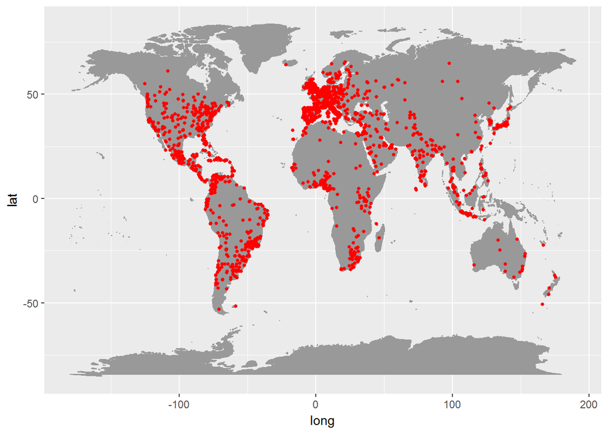

```r
# De manera general creamos un mapa de visualización del conjunto de datos
# de twitts con sus coordenadas establecidas
mapaMundi <- borders("world", colour="gray60", fill="gray60")
mapa <- ggplot() + mapaMundi
mapa <- mapa + geom_point(aes(x=geocoded$long, y=geocoded$lat),
                          color="red", size=1)
mapa
```

### 2.2.7 Carga del fichero shapefile: paises_generalizados

En este paso procedemos a la carga de los datos del shapefile # paises generaliados para realizar los cómputos posteriores:

```r
# Carga del fichero
paises_generalizados <- readOGR("./PAISES_GENERALIZADOS/paises_generalizados.shp")

# Convierte el dataframe geocoded_02 en un Spatial object
#coordinates(geocoded_02) <- 2:1
coordinates(geocoded) <- 2:1

# formato del objeto spatial
crs_geograficas ='+proj=longlat +ellps=WGS84 +datum=WGS84 +no_defs'
#geocoded_02@proj4string <-CRS(crs_geograficas)
geocoded@proj4string <-CRS(crs_geograficas)
paises_generalizados@proj4string <- CRS(crs_geograficas)

# Se crea un nuevo atributo 'contador' y lo inicializamos a 1
geocoded$contador <- 1
usuarios.pais <- aggregate(x=geocoded,
                           by=paises_generalizados,
                           FUN= length)
```

### 2.2.8 Guardamos el conjunto de datos en formato SHP: exportación para uso en ArcGIS

Finalmente, procedemos a exportar el objeto **‘paises_generalizados’** a un shapefile para poder utilizarlo en la plataforma ArcGIS

```r
writeOGR(paises_generalizados,
         "./paises_OGM/paises_twitter.shp",
         driver="ESRI Shapefile",
         layer="paises")
```

El resultado se encuentra en la dirección web: https://arcg.is/aWWvL

Tanto el código fuente como los resultados de la utilización del mismo se encuentran en un repositorio en **GitHub**, en la dirección: https://github.com/rgarciarui/geoTwitterRussia2018

# 3 Ejercicio 2: Generación de mapas de contaminación

En los últimos años, la contaminación atmosférica se está convirtiendo en un grave problema en los entornos urbanos. En ciudades como Madrid, los altos niveles de contaminación están provocando un grave problema de salud pública. El Ayuntamiento de la ciudad ha decidido tomar una serie de polémicas medidas, que afectan sobre todo a la circulación de vehículos privados, con el fin de reducir la emisión de estos contaminantes y en especial del dióxido de nitrógeno (NO2). El objetivo del ejercicio es la generación de dos mapas, uno utilizando el interpolador IDW y otro utilizando krigeaje, del máximo nivel de contaminación diaria para NO2 en la ciudad de Madrid. Durante el ejercicio se utilizará R como entorno para el tratamiento de los datos.

## 3.1 Desarrollo

Para el desarrollo del ejercicio utilizaremos los siguientes conjuntos de datos: * Datos en tiempo real de calidad del aire: https://goo.gl/BMLJ8X. Utilizaremos el archivo etiquetado como **“Calidad del aire. Tiempo real csv”**. Tened en cuenta que este fichero se actualiza cada hora. La descripción del conjunto de datos puede encontrarse en https://goo.gl/tBnK1o.

- Estaciones de control: https://goo.gl/AuCxvu. Utilizaremos el fichero etiquetado como **“Calidad del aire: estaciones de control”**, en formato xls. Las coordenadas se encuentran codificadas como coordenadas geográficas sexagesimales, con datum de referencia WGS84.
- Límites geográficos de los distritos de Madrid: https://goo.gl/SdZiH1. Utilizaremos el fichero etiquetado como **“Distritos en formato geográfico en ETRS89”**. El fichero shapefile contiene los límites municipales en sistema de coordenadas EPSG:25830.

El procedimiento propuesto incluye los siguientes pasos:

- Descarga de la información indicada.
- Lectura de los ficheros de datos con R.
- Cálculo de las coordenadas geográficas de localización de las estaciones a partir de las coor-denadas sexagesimales codificadas en los datos originales.
- Obtención del valor máximo horario de contaminación por NO2 para cada estación (los datos de dióxido de nitrógeno vienen codificados con el valor 8 en el campo magnitud).
- Asociación de los datos de contaminación con la localización geográfica de cada estación.
- Reproyección de la capa de límites municipales y obtención de un polígono único con el límite del municipio.
- Elaboración de los mapas requeridos. En ambos casos se podrán utilizar diferentes juegos de parámetros.